# k-Means for clustering

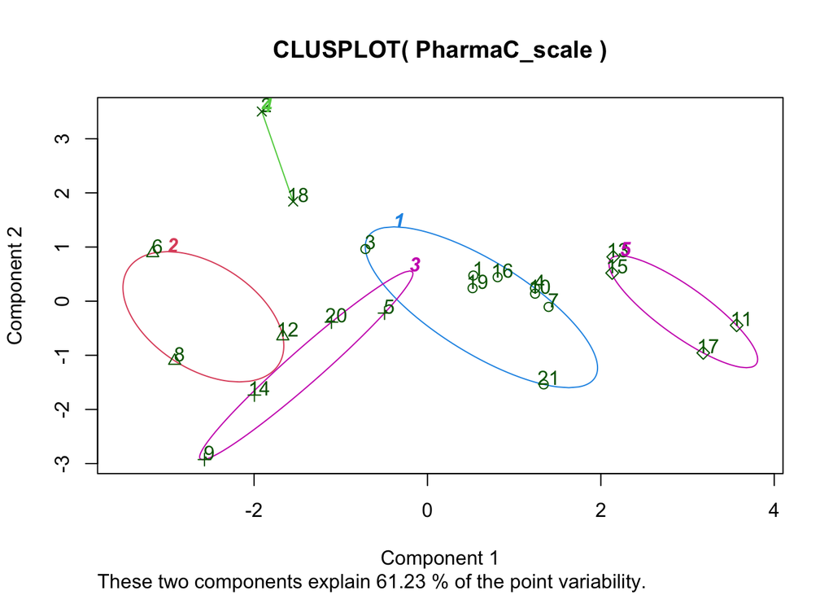

```r
clusplot(PharmaC_scale,final_C$cluster, color = TRUE, labels = 2,lines = 0)
```

```r
#b) Interpret the clusters with respect to the numerical variables used in forming the clusters.

#Cluster 1 - 1,3,4,7,10,16,19,21 ( lowest Market_Cap,lowest Beta,lowest PE_Ratio,highest Leverage,highest Rev_Growth.)

#Cluster 2 - 6, 8, 12 (lowest Rev_Growth,highest Beta and levearge,lowest Net_Profit_Margin)

#Cluster 3 - 5, 9, 14, 20 (lowest PE_Ratio,highest ROE,lowest ROA,lowest Net_Profit_Margin, highest Rev_Growth)

#Cluster 4 - 2, 18 (lowest Beta,lowest Asset_Turnover, Highest PE Ratio)

#Cluster 5 - 11, 13, 15, 17 (Highest Market_Cap,ROE, ROA,Asset_Turnover Ratio and lowest Beta/PE Ratio)

PC_Cluster <- PharmaC[,c(12,13,14)]%>% mutate(clusters = final_C$cluster)%>% arrange(clusters, ascending = TRUE)
PC_Cluster
```

| Median_Recommendation | Location | Exchange | clusters |
| --- | --- | --- | --- |
| Moderate Buy | US | NYSE | 1 |
| Strong Buy | UK | NYSE | 1 |
| Moderate Sell | UK | NYSE | 1 |
| Moderate Sell | US | NYSE | 1 |
| Hold | US | NYSE | 1 |
| Hold | SWITZERLAND | NYSE | 1 |
| Hold | US | NYSE | 1 |
| Hold | US | NYSE | 1 |
| Hold | GERMANY | NYSE | 2 |
| Moderate Buy | US | NASDAQ | 2 |

[output cut: 11 more lines]

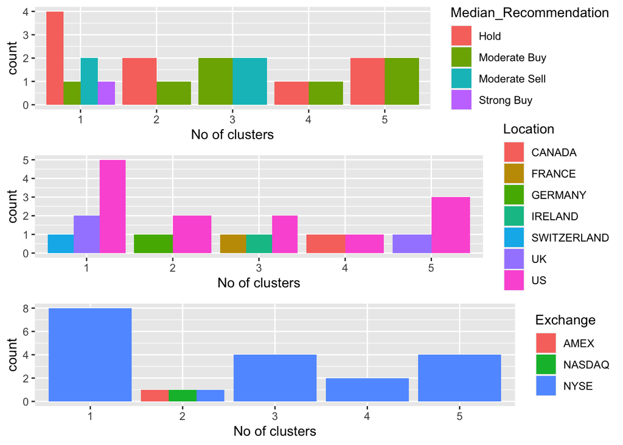

```r
#Task3
#In terms of the numerical, are there any clusters that exhibit a pattern. (10 to 12) variables? (those n not utilized in the cluster formation).


plot1_nr<-ggplot(PC_Cluster, mapping = aes(factor(clusters), fill=Median_Recommendation))+geom_bar(position = 'dodge')+labs(x ='No of clusters')
plot2_nr<- ggplot(PC_Cluster, mapping = aes(factor(clusters),fill = Location))+geom_bar(position = 'dodge')+labs(x ='No of clusters')
plot3_nr<- ggplot(PC_Cluster, mapping = aes(factor(clusters),fill = Exchange))+geom_bar(position = 'dodge')+labs(x ='No of clusters')
grid.arrange(plot1_nr, plot2_nr, plot3_nr)
```

#As per graph:-

#Cluster 1 :In this cluster, which also includes distinct Hold, Moderate Buy, Moderate Sell, and Strong Buy medians, the Hold median is the highest. They are from the US, the UK, and Switzerland and are traded on the NYSE.

#Cluster 2:AMEX, NASDAQ, and NYSE all have an equal distribution of companies, but there is a clear Hold and Moderate Buy median as well as a different count between the US and Germany.

#Cluster 3: listed on the NYSE, has distinct counts for France, Ireland, and the US, and has medians for buy and sell orders that are equally moderate.

#With respect to media Recommendation Variable ,the clusters follow a particular pattern: #Cluster 1 and Cluster 2 has Hold Recommendation. #Cluster 3, Cluster 4and Cluster 5 has moderate buy Recommendation.

```r
# (d) Give each cluster a suitable name using any or all of the dataset's variables.

#Cluster 1 :-  HIGH HOLD CLUSTER
#Cluster 2 :- HOLD CLUSTER
#Cluster 3 :- BUY-SELL CLUSTER
#Cluster 4 :- HOLD-BUY CLUSTER
#Cluster 5 :- HOLD-BUY CLUSTER
```